# KPI_defects_unit

## 🎯 Project Goal

This project implements a complete **Data Lakehouse pipeline** using  
**PySpark, Delta Lake, and the Medallion Architecture (Bronze → Silver → Gold)**.

The pipeline processes raw **procurement & supplier logistics data** stored in CSV files,  
performs validation, cleaning, transformation, feature engineering, and produces  
**supplier-level aggregated metrics** ready for analytics and BI consumption.

The purpose of the project is to demonstrate practical **Data Engineering skills**:

- distributed processing with **PySpark**
- **Delta Lake** ACID layers
- **data validation & schema control**
- **logging & error handling**
- feature engineering and aggregations
- robust architecture with **scalability & disaster recovery considerations**

## 🧰 Technologies and Tools

| Category | Technology | Purpose |
| --- | --- | --- |
| Distributed Processing | **PySpark** | ETL, transformations, aggregations |
| Storage | **Delta Lake** | ACID storage, schema evolution, time travel |
| Architecture | **Medallion (Bronze / Silver / Gold)** | Layered data refinement |
| Monitoring | `logging` | Data quality logs, errors, processing steps |
| Environment | JupyterLab (Docker) | Distributed data lake processing |

## 🥉 Bronze Layer – Raw Data with Basic Validation

The Bronze layer stores **raw** data in Delta Lake format.

### ✔ What happens in this layer?

This layer represents data **as received from source systems**, without transformations.

## 🥈 Silver Layer – Cleaning, Normalization & Feature Engineering

The Silver layer transforms the Bronze dataset into a **clean, typed, and analytics-ready** form.

### ✔ Data Cleaning & Normalization

- Convert fake null values (`"NULL"`, `"NA"`, `"nan"`, empty strings) to actual nulls
- Convert `Order_Date` and `Delivery_Date` to proper `DATE` type
- Drop rows with nulls in key columns:
  - `Supplier`
  - `Delivery_Date`
  - `Defective_Units`
- Remove duplicate records
- Enforce consistent data types across numeric columns

### ✔ Feature Engineering

- Create `Year_Delivery_Date` extracted from `Delivery_Date`
- Compute `Days_Difference` as the number of days between `Order_Date` and `Delivery_Date`

At this stage, the dataset is fully cleaned, typed, enriched, and ready for aggregation.

## 🥇 Gold Layer – Supplier-Level Aggregations

The Gold layer produces **business-ready aggregated datasets** at supplier granularity.

### 📌 Aggregation Logic

Data is grouped by:

- `Supplier`
- `Year_Delivery_Date`

### 📊 Example Metrics Produced

- Total number of orders
- Total quantity delivered
- Average delivery lead time (`Days_Difference`)
- Total defective units per supplier and year

### ✔ Final Steps

- Perform aggregations using PySpark
- Write results as **Gold Delta tables**
- Optimize structure for BI tools and downstream analytics

This layer serves as the **single source of truth** for supplier performance analysis.

## 🏗️ Architecture – Medallion, Scalability & Reliability

The project follows a **Medallion Architecture** design pattern:

**Bronze → Silver → Gold**

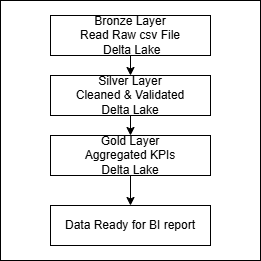

### Scalability & Performance

- Distributed Spark processing
- Delta Lake optimized for large-scale data
- Partitioning by `Year_Delivery_Date`
- Compute scalability via Spark execution model

### Reliability & Data Quality

- ACID transactions via Delta Lake
- Time Travel for data recovery and auditing
- Logging of each pipeline stage
- Data validation at every layer

This architecture mirrors production-grade data lakehouse pipelines.

## 📊 Consumption Layer

The Gold Delta tables are designed for easy consumption by analytics tools such as:

- Power BI
- SQL engines
- Data exploration notebooks

They enable supplier performance analysis, defect tracking, and delivery lead-time monitoring.

## 🚀 Possible Enhancements

- Add orchestration layer (Airflow / Databricks Workflows)
- Introduce unit tests for transformation logic
- Implement Great Expectations for data quality checks
- Add CDC-based ingestion
- Expose Gold tables via SQL endpoints
- Build monitoring dashboards for pipeline health

## 🧠 What I Learned

- Designing and implementing distributed ETL pipelines with **PySpark**
- Applying **Medallion Architecture** in practice
- Using **Delta Lake** for reliable, transactional storage
- Enforcing data quality through validation and logging
- Performing feature engineering on logistics data
- Aggregating supplier-level metrics for analytics
- Building scalable, production-style data pipelines